# 611 Project Report

Teya Davis

2023-12-14

# Analysis of Forbes’ Lists of Richest Athletes from 1990 to 2020

Forbes magazine has produced and published a list of the richest professional athletes since 1990. The list ranks the athletes, across all sports, in terms of their yearly income and provides other information about each athlete. Among this information is the athlete’s respective sport, their total income, and, added more recently, a break down of the athlete’s income. In the lists of recent years, the athlete’s earnings on the field and off the field have also been reported.

The income year that the Forbes list reports on lasts from June until June. This is a change from how it was compiled when the list was first produced. The reporting period was originally the calendar year. The switch was made in 2002, making it so that there is no list for the 2001 year.

## Introduction

The data I have chosen gives a summary of these lists produced by Forbes. For the years between 1990 and 2020, the data includes information about the ranks of the athletes by income for the year, their rank the previous year, the names of the athletes, the athletes’ income for the year, and the athletes’ nationalities.

From this data, I have several questions. A few of them are: How do professional athletes’ salaries compare to one another? What trends are there among them? Is an athlete’s home country related to how much they are paid? How has the salary of the highest paid athlete has changed over time? Which athlete has appeared the most on the list? Can the highest paid athletes in a particular sport be grouped together in terms of amount of money earned? Which sports are consistently producing the highest paid athlete each year?

I will answer a few of these questions in the analysis that I conduct on this data and leave the rest for future investigation.

## Exploratory Data Analysis

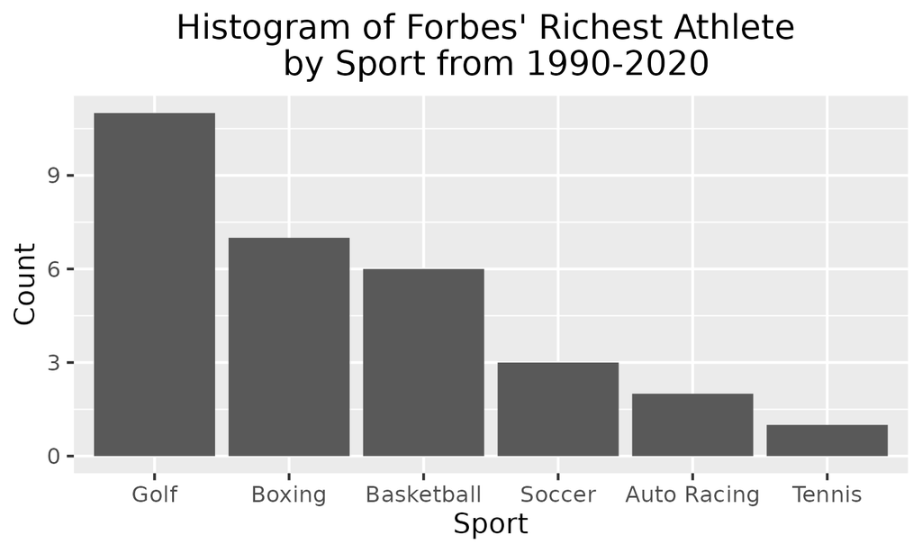

Histogram 1

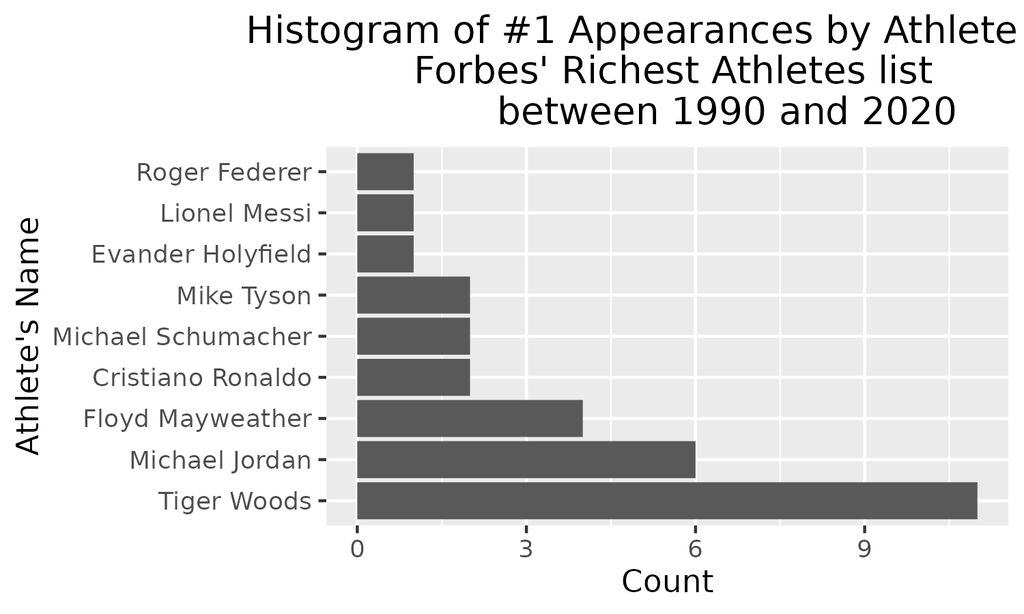

Histogram 2

- Following my investigation of the sports that were producing the number 1 highest paid athlete each year, I went on to look at which athletes were consistently at the top of the Forbes list each year. As we can see from this histogram, Tiger Woods made the most appearances at the top of the Forbes List for Richest Athletes between the years of 1990 and 2020. Tiger Woods topped the list for 10 consecutive years from 2002 to 2011. Following Tiger Woods is UNC’s very own, Michael Jordan. Michael Jordan topped the list for 4 consecutive years from 1992 to 1995.

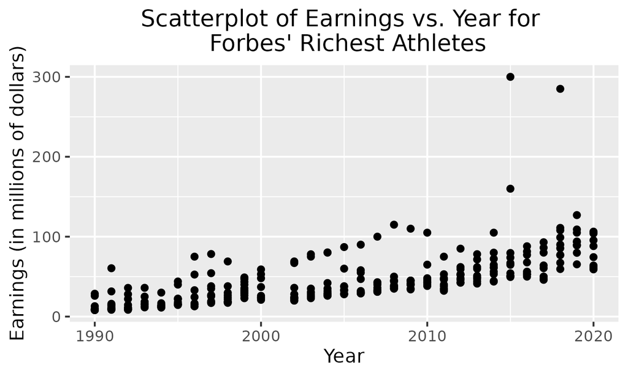

Scatterplot 1

- To answer the question of how the salaries of the richest paid athletes have changed over time, I chose to make a scatter plot of the athletes’ earnings vs. the year. From this plot, we can see a subtle increasing trend of the salaries of the richest athletes over time. This was what I expected. As sports become increasingly popular entertainment worldwide and athletes begin to make money off the court through brand deals and other means, this trend is justifiable.

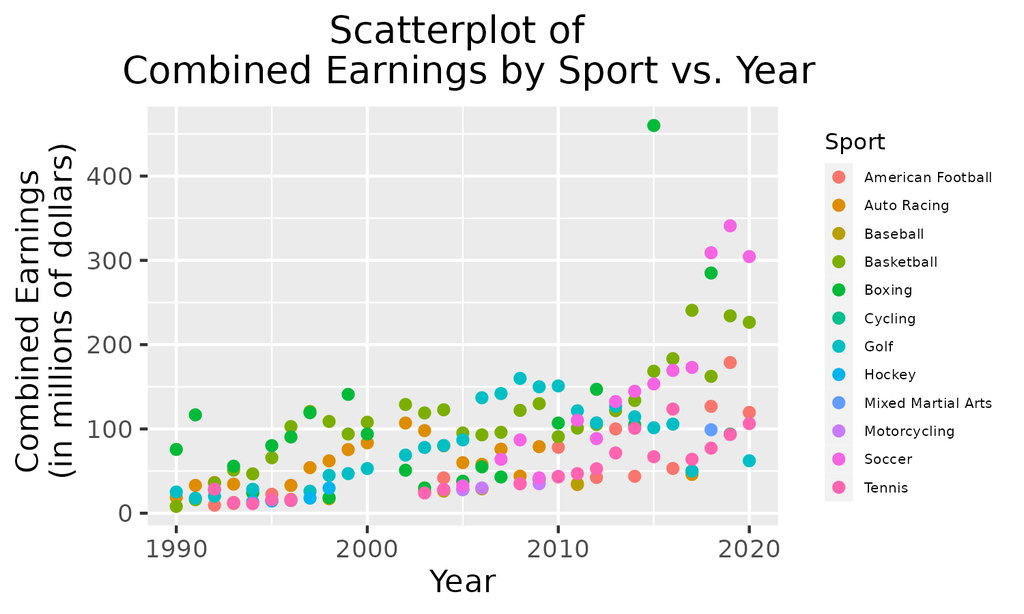

Scatterplot 2

- Further investigating trends in the salaries of the highest paid athletes over time, I chose to create a scatter plot of the combined earnings for the athletes of a particular sport vs. the year. In the beginning years of the Forbes List of Richest Athletes, we see that, combined, basketball players and boxers earned the most. In the later 2000s (2005-2010), we see that, combined, golfers earned the most. More recently, we see that soccer players, combined, have been earning the most. The huge outlier that we see at 2015 is the combined salary of boxers for that year. In 2015, Floyd Mayweather earned $300 million, pulling boxing way up to the top of combined earnings for that year.

## Principal Components Analysis

- To investigate whether or not the highest paid athletes can be grouped together in any way, we will run principal components analysis.

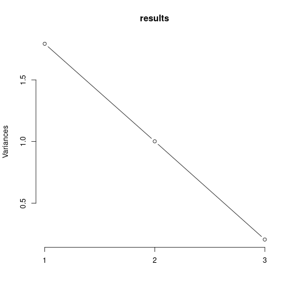

PCA Part 1

- Once we plot the variances as a function of the number of components, we can see that most of the variance in the data is explained by the first two principal components.

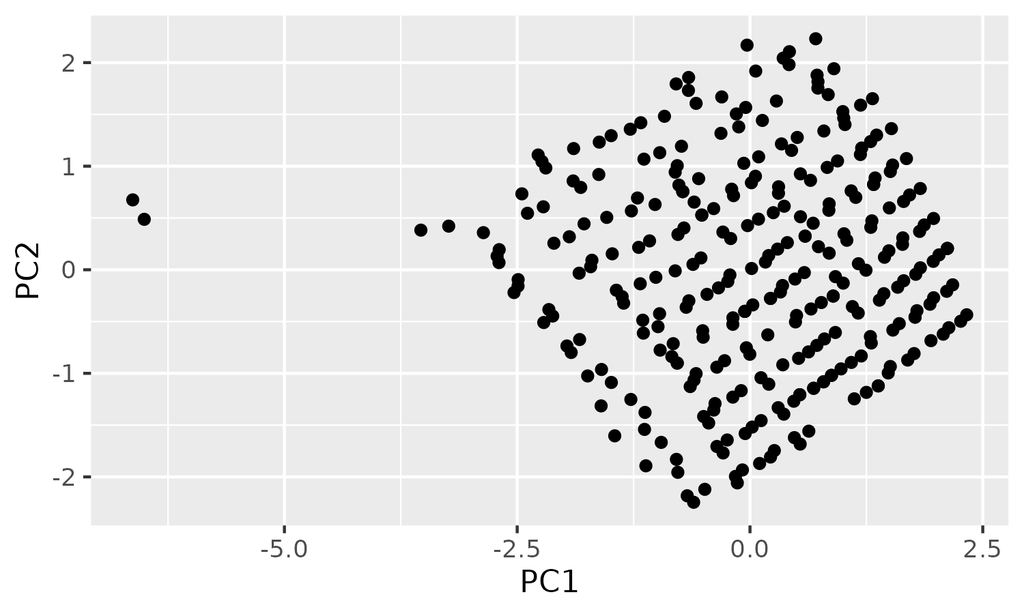

PCA Part 2

- After plotting the second principal component against the first principal component, we can see that there are not any definitive clusters among the data.

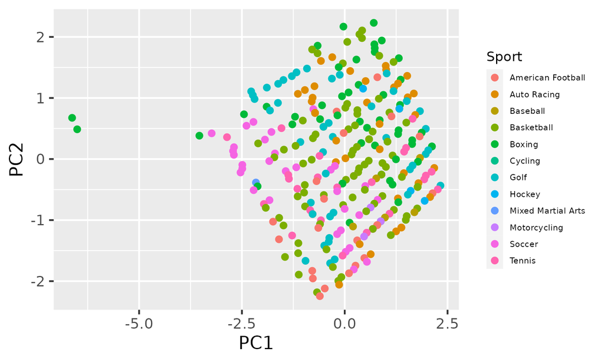

PCA Part 3

- After coloring the data based on the sport associated with each point, we see that there are no definitive groups of sports among the data either. With this, we conclude that there are not significant clusters within the data that we analyzed.

## Future Analysis

- In the future, analysis can be done to answer some of the questions that I posed that I did not investigate like: Is an athlete’s home country related to how much they are paid? Analysis can also be done to investigate how much of an athlete’s earnings come from on the field vs. off the field. Further, the position of women on the Forbes List of Richest Athletes in their respective sports can be done in comparison with their male counterparts. As the data for this subject will grow each year, I believe that there are and will be even more interesting things to look at and investigate from it as time goes on.